# strachan_campylo

assemblycomparator2 Report

2023-05-26 09:40:58

This report was generated using the results located at /home/thylakoid/pnytera/aa_databases/10_supacow/dbF2/strachan_campylo/results_ac2 using the installation at /home/thylakoid/assemblycomparator2.

## Samples

| input_file | sample |
| --- | --- |
| GCF_027736965.1_ASM2773696v1_genomic.fna | GCF_027736965.1_ASM2773696v1_genomic |
| GCF_027736975.1_ASM2773697v1_genomic.fna | GCF_027736975.1_ASM2773697v1_genomic |
| GCF_027736985.1_ASM2773698v1_genomic.fna | GCF_027736985.1_ASM2773698v1_genomic |
| GCF_027737105.1_ASM2773710v1_genomic.fna | GCF_027737105.1_ASM2773710v1_genomic |
| GCF_027737145.1_ASM2773714v1_genomic.fna | GCF_027737145.1_ASM2773714v1_genomic |
| GCF_027737225.1_ASM2773722v1_genomic.fna | GCF_027737225.1_ASM2773722v1_genomic |
| GCF_027737245.1_ASM2773724v1_genomic.fna | GCF_027737245.1_ASM2773724v1_genomic |
| GCF_027737305.1_ASM2773730v1_genomic.fna | GCF_027737305.1_ASM2773730v1_genomic |
| GCF_027737365.1_ASM2773736v1_genomic.fna | GCF_027737365.1_ASM2773736v1_genomic |
| GCF_027737405.1_ASM2773740v1_genomic.fna | GCF_027737405.1_ASM2773740v1_genomic |

[output cut: 24 more lines]

*Table 1: Overview of the samples analysed in this batch.*

### Report sections

Here is an overview of the number of result files that have been found for each analysis. A report section is only rendered if relevant result files are present for that analysis. Each section can be triggered to run by calling assemblycomparator2 with a trailing `--until <section>`

| section | n / expected | render |
| --- | --- | --- |
| assembly_stats | 1 / 1 | 🟢 yes |
| sequence_lengths | 34 / 34 | 🟢 yes |
| busco | 34 / 34 | 🟢 yes |
| checkm2 | 1 / 1 | 🟢 yes |
| kraken2 | 34 / 34 | 🟢 yes |
| gtdbtk | 1 / 1 | 🟢 yes |
| mlst | 1 / 1 | 🟢 yes |
| abricate | 4 / 4 | 🟢 yes |
| prokka | 34 / 34 | 🟢 yes |
| roary | 1 / 1 | 🟢 yes |

[output cut: 1 more lines]

*Table 2: Overview of sections that are rendered in this report. “n / expected” shows the number of analysis files versus how many are expected to be present. Sections are only rendered if relevant files exist. Analyses that perform comparisons between samples generally only output one set of results independent on the number of input files*

## Assembly statistics

| sample | total_length | number | mean_length | longest | shortest | N_count | Gaps | N50 | N90 |
| --- | --- | --- | --- | --- | --- | --- | --- | --- | --- |
| GCF_027736965.1_ASM2773696v1_genomic | 1554452 | 11 | 141313.82 | 693590 | 1328 | 0 | 0 | 268134 | 109207 |
| GCF_027736975.1_ASM2773697v1_genomic | 1557444 | 11 | 141585.82 | 698760 | 1851 | 0 | 0 | 268132 | 86483 |
| GCF_027736985.1_ASM2773698v1_genomic | 1574054 | 26 | 60540.54 | 456653 | 1005 | 0 | 0 | 185432 | 88652 |
| GCF_027737105.1_ASM2773710v1_genomic | 1561367 | 16 | 97585.44 | 374815 | 1690 | 0 | 0 | 149092 | 50691 |
| GCF_027737145.1_ASM2773714v1_genomic | 1559413 | 16 | 97463.31 | 298889 | 1397 | 0 | 0 | 185312 | 69743 |
| GCF_027737225.1_ASM2773722v1_genomic | 1599480 | 12 | 133290 | 435348 | 1090 | 0 | 0 | 244497 | 128899 |
| GCF_027737245.1_ASM2773724v1_genomic | 1592905 | 9 | 176989.44 | 456769 | 1090 | 0 | 0 | 415972 | 128903 |
| GCF_027737305.1_ASM2773730v1_genomic | 1596272 | 10 | 159627.2 | 460632 | 1090 | 0 | 0 | 415498 | 123448 |
| GCF_027737365.1_ASM2773736v1_genomic | 1692523 | 27 | 62686.04 | 582255 | 1016 | 0 | 0 | 474971 | 108096 |
| GCF_027737405.1_ASM2773740v1_genomic | 1578663 | 15 | 105244.2 | 353365 | 1084 | 0 | 0 | 224357 | 82685 |

[output cut: 24 more lines]

*Table 3: Assembly statistics is provided by assembly-stats. N50 indicates the length of the smallest contig that (together with the longer contigs) covers at least half of the genome.*

## Contig sizes and GC-content

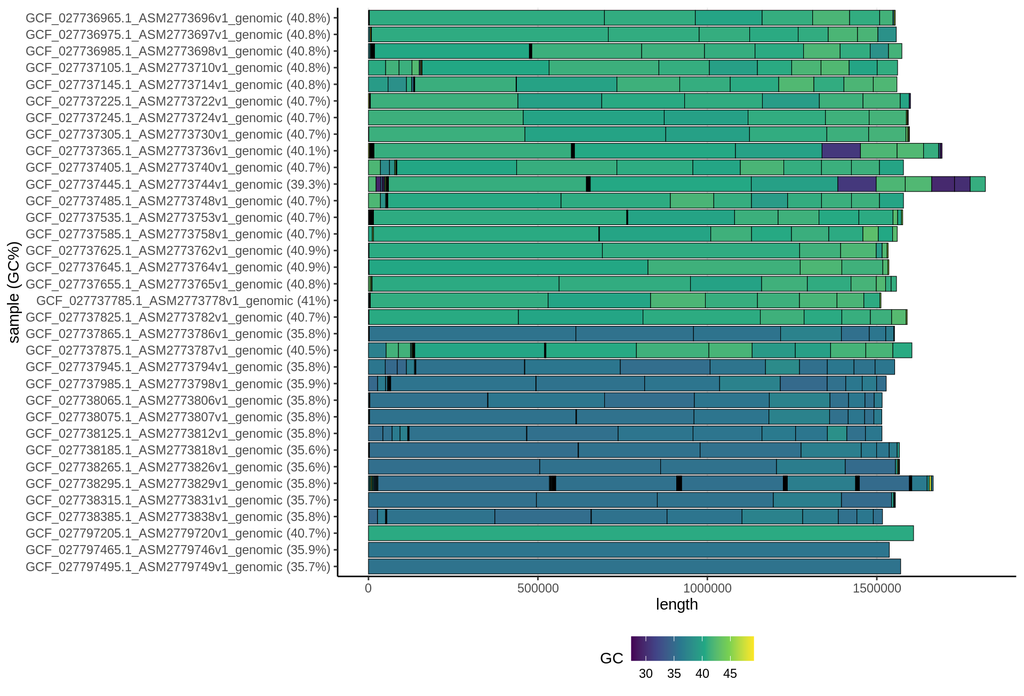

*Fig. 1: Visualization of the length of each fasta record for each sample. The colors show the mean GC content for each record (contig).*

## BUSCO

| sample | lineage | C | S | D | F | M | n |
| --- | --- | --- | --- | --- | --- | --- | --- |
| GCF_027736965.1_ASM2773696v1_genomic | bacteria_odb10 | 89.5 | 89.5 | 0 | 4 | 6.5 | 124 |
| GCF_027736975.1_ASM2773697v1_genomic | bacteria_odb10 | 90.3 | 90.3 | 0 | 3.2 | 6.5 | 124 |
| GCF_027736985.1_ASM2773698v1_genomic | bacteria_odb10 | 89.5 | 89.5 | 0 | 4 | 6.5 | 124 |
| GCF_027737105.1_ASM2773710v1_genomic | bacteria_odb10 | 90.3 | 90.3 | 0 | 3.2 | 6.5 | 124 |
| GCF_027737145.1_ASM2773714v1_genomic | bacteria_odb10 | 89.5 | 89.5 | 0 | 4 | 6.5 | 124 |
| GCF_027737225.1_ASM2773722v1_genomic | bacteria_odb10 | 89.5 | 89.5 | 0 | 4 | 6.5 | 124 |
| GCF_027737245.1_ASM2773724v1_genomic | bacteria_odb10 | 89.5 | 89.5 | 0 | 4 | 6.5 | 124 |
| GCF_027737305.1_ASM2773730v1_genomic | bacteria_odb10 | 89.5 | 89.5 | 0 | 4 | 6.5 | 124 |
| GCF_027737365.1_ASM2773736v1_genomic | bacteria_odb10 | 89.5 | 89.5 | 0 | 4 | 6.5 | 124 |
| GCF_027737405.1_ASM2773740v1_genomic | bacteria_odb10 | 90.3 | 90.3 | 0 | 3.2 | 6.5 | 124 |

[output cut: 24 more lines]

*Table 4: Table of [BUSCO](https://busco.ezlab.org/) “BUSCO estimates the completeness and redundancy of processed genomic data based on universal single-copy orthologs.”. The following columns are printed as percents [%]: C: Complete, S: Complete and single-copy, D: Complete and duplicated, F: Fragmented, M: Missing, n: Total BUSCO groups searched. For each sample, only the best lineage match (in terms of completeness) is shown.*

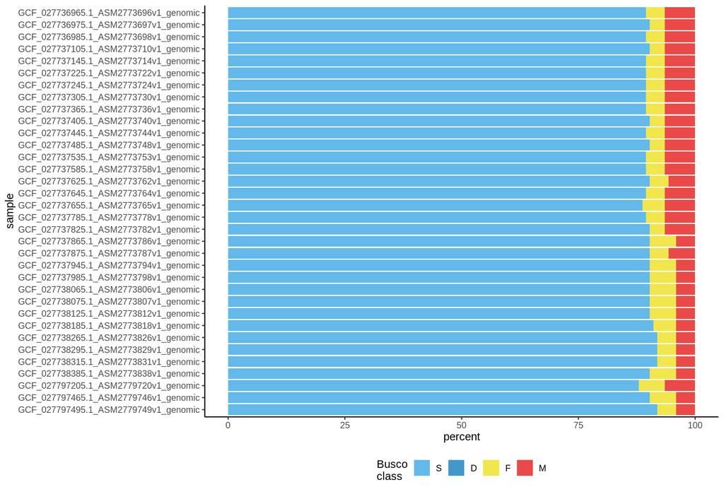

*Fig. 2: BUSCO results visualized. Legend: S: Complete and single-copy; D: Complete and duplicated; F: Fragmented; M: Missing. For each sample, only the best lineage match (in terms of completeness) is shown.*

## Checkm2

| sample | Completeness | Contamination | Completeness Model Used | Translation Table Used | Coding Density | Contig N50 | Average Gene Length | Genome Size | GC Content | Total Coding Sequences | Additional Notes |
| --- | --- | --- | --- | --- | --- | --- | --- | --- | --- | --- | --- |
| GCF_027736965.1_ASM2773696v1_genomic | 99.95 | 0 | Neural Network (Specific Model) | 11 | 0.92 | 268134 | 306.8 | 1554452 | 0.41 | 1557 | None |
| GCF_027736975.1_ASM2773697v1_genomic | 99.99 | 0 | Neural Network (Specific Model) | 11 | 0.921 | 268132 | 307 | 1557444 | 0.41 | 1561 | None |
| GCF_027736985.1_ASM2773698v1_genomic | 99.97 | 0.04 | Neural Network (Specific Model) | 11 | 0.92 | 185432 | 306.6 | 1574054 | 0.41 | 1578 | None |
| GCF_027737105.1_ASM2773710v1_genomic | 99.99 | 0 | Neural Network (Specific Model) | 11 | 0.92 | 149092 | 306.9 | 1561367 | 0.41 | 1564 | None |
| GCF_027737145.1_ASM2773714v1_genomic | 99.99 | 0.01 | Neural Network (Specific Model) | 11 | 0.92 | 185312 | 306.5 | 1559413 | 0.41 | 1565 | None |
| GCF_027737225.1_ASM2773722v1_genomic | 99.99 | 0.01 | Neural Network (Specific Model) | 11 | 0.917 | 244497 | 306.8 | 1599480 | 0.41 | 1598 | None |
| GCF_027737245.1_ASM2773724v1_genomic | 99.99 | 0 | Neural Network (Specific Model) | 11 | 0.917 | 415972 | 307.5 | 1592905 | 0.41 | 1588 | None |
| GCF_027737305.1_ASM2773730v1_genomic | 99.98 | 0 | Neural Network (Specific Model) | 11 | 0.917 | 415498 | 307.4 | 1596272 | 0.41 | 1592 | None |
| GCF_027737365.1_ASM2773736v1_genomic | 99.99 | 0 | Neural Network (Specific Model) | 11 | 0.918 | 474971 | 297.1 | 1692523 | 0.4 | 1747 | None |
| GCF_027737405.1_ASM2773740v1_genomic | 99.98 | 0 | Neural Network (Specific Model) | 11 | 0.915 | 224357 | 310 | 1578663 | 0.41 | 1557 | None |

[output cut: 24 more lines]

*Table 5: [Checkm2](https://github.com/chklovski/CheckM2) results.*

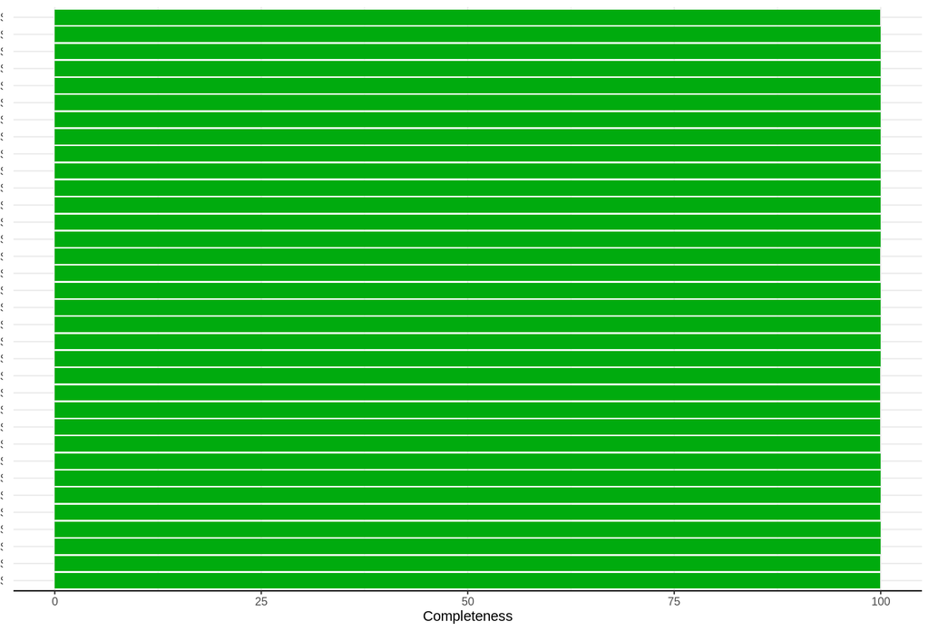

*Fig. 3: [Checkm2](https://github.com/chklovski/CheckM2) results. Axes are in percents.*

## Kraken2

| sample | unclassified | domain | phylum | class | order | family | genus | species |
| --- | --- | --- | --- | --- | --- | --- | --- | --- |
| GCF_027736965.1_ASM2773696v1_genomic | unclassified 18.2% | Bacteria 81.8% | Campylobacterota 81.8% | Epsilonproteobacteria 81.8% | Campylobacterales 81.8% | Campylobacteraceae 81.8% | Campylobacter 81.8% | Campylobacter sp. VBCF_01 NA2 63.6% |
| GCF_027736975.1_ASM2773697v1_genomic | unclassified 9.1% | Bacteria 90.9% | Campylobacterota 90.9% | Epsilonproteobacteria 90.9% | Campylobacterales 90.9% | Campylobacteraceae 90.9% | Campylobacter 90.9% | Campylobacter sp. VBCF_01 NA2 72.7% |
| GCF_027736985.1_ASM2773698v1_genomic | unclassified 19.2% | Bacteria 80.8% | Campylobacterota 80.8% | Epsilonproteobacteria 80.8% | Campylobacterales 80.8% | Campylobacteraceae 80.8% | Campylobacter 80.8% | Campylobacter sp. VBCF_01 NA2 42.3% |
| GCF_027737105.1_ASM2773710v1_genomic | unclassified 6.2% | Bacteria 93.8% | Campylobacterota 93.8% | Epsilonproteobacteria 93.8% | Campylobacterales 93.8% | Campylobacteraceae 93.8% | Campylobacter 93.8% | Campylobacter sp. VBCF_01 NA2 81.2% |
| GCF_027737145.1_ASM2773714v1_genomic | unclassified 6.2% | Bacteria 93.8% | Campylobacterota 93.8% | Epsilonproteobacteria 93.8% | Campylobacterales 93.8% | Campylobacteraceae 93.8% | Campylobacter 93.8% | Campylobacter sp. VBCF_01 NA2 81.2% |
| GCF_027737225.1_ASM2773722v1_genomic | - | Bacteria 100% | Campylobacterota 100% | Epsilonproteobacteria 100% | Campylobacterales 100% | Campylobacteraceae 100% | Campylobacter 100% | Campylobacter sp. VBCF_01 NA2 83.3% |
| GCF_027737245.1_ASM2773724v1_genomic | - | Bacteria 100% | Campylobacterota 100% | Epsilonproteobacteria 100% | Campylobacterales 100% | Campylobacteraceae 100% | Campylobacter 100% | Campylobacter sp. VBCF_01 NA2 77.8% |
| GCF_027737305.1_ASM2773730v1_genomic | - | Bacteria 100% | Campylobacterota 100% | Epsilonproteobacteria 100% | Campylobacterales 100% | Campylobacteraceae 100% | Campylobacter 100% | Campylobacter sp. VBCF_01 NA2 80% |
| GCF_027737365.1_ASM2773736v1_genomic | unclassified 25.9% | Bacteria 74.1% | Campylobacterota 74.1% | Epsilonproteobacteria 74.1% | Campylobacterales 74.1% | Campylobacteraceae 74.1% | Campylobacter 74.1% | Campylobacter sp. CN_NE2 44.4% |
| GCF_027737405.1_ASM2773740v1_genomic | - | Bacteria 100% | Campylobacterota 100% | Epsilonproteobacteria 100% | Campylobacterales 100% | Campylobacteraceae 100% | Campylobacter 100% | Campylobacter sp. VBCF_01 NA2 86.7% |

[output cut: 24 more lines]

*Table 6: Kraken2 results. For each sample, only the best hit is shown. Taxonomical identification is provided by [Kraken 2](https://github.com/DerrickWood/kraken2/wiki/About-Kraken-2). The percentages indicate the number of fragments that are covered by the respective clade.*

## GTDB taxonomical classification

[GTDB](https://gtdb.ecogenomic.org/) uses several public repositories with reference sequences and assigns the most likely name by measuring the average nucleotide identity (ANI) and relative evolutionary divergence (RED).

| sample | classification | fastani_ani | fastani_reference | msa_percent | red_value |
| --- | --- | --- | --- | --- | --- |
| GCF_027736965.1_ASM2773696v1_genomic | d__Bacteria;p__Campylobacterota;c__Campylobacteria;o__Campylobacterales;f__Campylobacteraceae;g__Campylobacter_B;s__Campylobacter_B sp017934385 | 95.95 | GCA_017934385.1 |  |  |
| GCF_027736975.1_ASM2773697v1_genomic | d__Bacteria;p__Campylobacterota;c__Campylobacteria;o__Campylobacterales;f__Campylobacteraceae;g__Campylobacter_B;s__Campylobacter_B sp017934385 | 95.95 | GCA_017934385.1 |  |  |
| GCF_027736985.1_ASM2773698v1_genomic | d__Bacteria;p__Campylobacterota;c__Campylobacteria;o__Campylobacterales;f__Campylobacteraceae;g__Campylobacter_B;s__Campylobacter_B sp017934385 | 95.93 | GCA_017934385.1 |  |  |
| GCF_027737105.1_ASM2773710v1_genomic | d__Bacteria;p__Campylobacterota;c__Campylobacteria;o__Campylobacterales;f__Campylobacteraceae;g__Campylobacter_B;s__Campylobacter_B sp017934385 | 95.93 | GCA_017934385.1 |  |  |
| GCF_027737145.1_ASM2773714v1_genomic | d__Bacteria;p__Campylobacterota;c__Campylobacteria;o__Campylobacterales;f__Campylobacteraceae;g__Campylobacter_B;s__Campylobacter_B sp017934385 | 95.91 | GCA_017934385.1 |  |  |
| GCF_027737225.1_ASM2773722v1_genomic | d__Bacteria;p__Campylobacterota;c__Campylobacteria;o__Campylobacterales;f__Campylobacteraceae;g__Campylobacter_B;s__Campylobacter_B sp017934385 | 95.98 | GCA_017934385.1 |  |  |
| GCF_027737245.1_ASM2773724v1_genomic | d__Bacteria;p__Campylobacterota;c__Campylobacteria;o__Campylobacterales;f__Campylobacteraceae;g__Campylobacter_B;s__Campylobacter_B sp017934385 | 95.91 | GCA_017934385.1 |  |  |
| GCF_027737305.1_ASM2773730v1_genomic | d__Bacteria;p__Campylobacterota;c__Campylobacteria;o__Campylobacterales;f__Campylobacteraceae;g__Campylobacter_B;s__Campylobacter_B sp017934385 | 96.03 | GCA_017934385.1 |  |  |
| GCF_027737365.1_ASM2773736v1_genomic | d__Bacteria;p__Campylobacterota;c__Campylobacteria;o__Campylobacterales;f__Campylobacteraceae;g__Campylobacter_B;s__Campylobacter_B sp017934385 | 95.97 | GCA_017934385.1 |  |  |
| GCF_027737405.1_ASM2773740v1_genomic | d__Bacteria;p__Campylobacterota;c__Campylobacteria;o__Campylobacterales;f__Campylobacteraceae;g__Campylobacter_B;s__Campylobacter_B sp017934385 | 95.87 | GCA_017934385.1 |  |  |

[output cut: 24 more lines]

*Table 7: Species classification provided by the GTDB-tk classify_wf workflow.*

## MLST

| sample | scheme | sequence_type |
| --- | --- | --- |
| GCF_027736965.1_ASM2773696v1_genomic | - | - |
| GCF_027736975.1_ASM2773697v1_genomic | - | - |
| GCF_027736985.1_ASM2773698v1_genomic | - | - |
| GCF_027737105.1_ASM2773710v1_genomic | - | - |
| GCF_027737145.1_ASM2773714v1_genomic | - | - |
| GCF_027737225.1_ASM2773722v1_genomic | - | - |
| GCF_027737245.1_ASM2773724v1_genomic | - | - |
| GCF_027737305.1_ASM2773730v1_genomic | - | - |
| GCF_027737365.1_ASM2773736v1_genomic | - | - |
| GCF_027737405.1_ASM2773740v1_genomic | - | - |

[output cut: 24 more lines]

*Table 8: Table of MLST (Multi Locus Sequence Typing) results. Called with mlst which incorporates components of the [PubMLST](https://pubmlst.org/) database.*

#### How to customize the mlst-analysis

Mlst automatically detects the best scheme for typing, one sample at a time. If you don’t agree with the automatic detection, you can enforce a single scheme across all samples by (re)running assemblycomparator2 with the added command-line argument: `--config mlst_scheme=hpylori --forcerun mlst`. Replace *hpylori* with the mlst scheme you wish to use. You can find a full list of available schemes in the “results_ac2/mlst/mlst_schemes.txt”.

## Antimicrobial Resistance

Using [Abricate](https://github.com/tseemann/abricate#abricate), the assemblies are scanned for known resistance genes in the ncbi, card, plasmidfinder and vfdb antimicrobial resistance databases.

#### NCBI AMRFinder

| sample | n |
| --- | --- |
| GCF_027736965.1_ASM2773696v1_genomic | 0 |
| GCF_027736975.1_ASM2773697v1_genomic | 0 |
| GCF_027736985.1_ASM2773698v1_genomic | 0 |
| GCF_027737105.1_ASM2773710v1_genomic | 0 |
| GCF_027737145.1_ASM2773714v1_genomic | 0 |
| GCF_027737225.1_ASM2773722v1_genomic | 0 |
| GCF_027737245.1_ASM2773724v1_genomic | 0 |
| GCF_027737305.1_ASM2773730v1_genomic | 0 |
| GCF_027737365.1_ASM2773736v1_genomic | 0 |
| GCF_027737405.1_ASM2773740v1_genomic | 0 |

[output cut: 24 more lines]

*Table 9: Table of NCBI Resistance gene calls called with [NCBI AMRFinder](https://www.ncbi.nlm.nih.gov/pmc/articles/PMC6811410/).*

#### CARD

| sample | n |
| --- | --- |
| GCF_027736965.1_ASM2773696v1_genomic | 0 |
| GCF_027736975.1_ASM2773697v1_genomic | 0 |
| GCF_027736985.1_ASM2773698v1_genomic | 0 |
| GCF_027737105.1_ASM2773710v1_genomic | 0 |
| GCF_027737145.1_ASM2773714v1_genomic | 0 |
| GCF_027737225.1_ASM2773722v1_genomic | 0 |
| GCF_027737245.1_ASM2773724v1_genomic | 0 |
| GCF_027737305.1_ASM2773730v1_genomic | 0 |
| GCF_027737365.1_ASM2773736v1_genomic | 0 |
| GCF_027737405.1_ASM2773740v1_genomic | 0 |

[output cut: 24 more lines]

*Table 10: Table of [CARD](https://card.mcmaster.ca/) (Comprehensive Antibiotic Resistance Database) results*

#### PlasmidFinder

| sample | n |
| --- | --- |
| GCF_027736965.1_ASM2773696v1_genomic | 0 |
| GCF_027736975.1_ASM2773697v1_genomic | 0 |
| GCF_027736985.1_ASM2773698v1_genomic | 0 |
| GCF_027737105.1_ASM2773710v1_genomic | 0 |
| GCF_027737145.1_ASM2773714v1_genomic | 0 |
| GCF_027737225.1_ASM2773722v1_genomic | 0 |
| GCF_027737245.1_ASM2773724v1_genomic | 0 |
| GCF_027737305.1_ASM2773730v1_genomic | 0 |
| GCF_027737365.1_ASM2773736v1_genomic | 0 |
| GCF_027737405.1_ASM2773740v1_genomic | 0 |

[output cut: 24 more lines]

*Table 11: Table of [PlasmidFinder](https://cge.cbs.dtu.dk/services/PlasmidFinder/) plasmid calls. Note that plasmidfinder uses short substrings for recognizing the plasmids, and not necessarily longer sequences i.e. complete plasmid sequences.*

#### VFDB

| sample | n |
| --- | --- |
| GCF_027736965.1_ASM2773696v1_genomic | 0 |
| GCF_027736975.1_ASM2773697v1_genomic | 0 |
| GCF_027736985.1_ASM2773698v1_genomic | 0 |
| GCF_027737105.1_ASM2773710v1_genomic | 0 |
| GCF_027737145.1_ASM2773714v1_genomic | 0 |
| GCF_027737225.1_ASM2773722v1_genomic | 0 |
| GCF_027737245.1_ASM2773724v1_genomic | 0 |
| GCF_027737305.1_ASM2773730v1_genomic | 0 |
| GCF_027737365.1_ASM2773736v1_genomic | 0 |
| GCF_027737405.1_ASM2773740v1_genomic | 0 |

[output cut: 24 more lines]

*Table 12: Table of [VFDB](http://www.mgc.ac.cn/VFs/main.htm) virulence factor calls: “An integrated and comprehensive online resource for curating information about virulence factors of bacterial pathogens”.*

## Genomic annotation

| sample | contigs | bases | CDS | misc_RNA | rRNA | tRNA | tmRNA | repeat_region |
| --- | --- | --- | --- | --- | --- | --- | --- | --- |
| GCF_027736965.1_ASM2773696v1_genomic | 11 | 1554452 | 1550 | 5 | 2 | 39 | 1 | 0 |
| GCF_027736975.1_ASM2773697v1_genomic | 11 | 1557444 | 1550 | 5 | 2 | 39 | 1 | 0 |
| GCF_027736985.1_ASM2773698v1_genomic | 26 | 1574054 | 1559 | 5 | 3 | 39 | 1 | 0 |
| GCF_027737105.1_ASM2773710v1_genomic | 16 | 1561367 | 1557 | 5 | 2 | 39 | 1 | 0 |
| GCF_027737145.1_ASM2773714v1_genomic | 16 | 1559413 | 1552 | 5 | 3 | 39 | 1 | 0 |
| GCF_027737225.1_ASM2773722v1_genomic | 12 | 1599480 | 1595 | 5 | 2 | 40 | 1 | 0 |
| GCF_027737245.1_ASM2773724v1_genomic | 9 | 1592905 | 1585 | 5 | 2 | 40 | 1 | 0 |
| GCF_027737305.1_ASM2773730v1_genomic | 10 | 1596272 | 1589 | 5 | 2 | 40 | 1 | 0 |
| GCF_027737365.1_ASM2773736v1_genomic | 27 | 1692523 | 1727 | 5 | 2 | 39 | 1 | 2 |
| GCF_027737405.1_ASM2773740v1_genomic | 15 | 1578663 | 1549 | 5 | 2 | 39 | 1 | 2 |

[output cut: 24 more lines]

*Table 13: Overview of the number of different gene types. Called using the [Prokka](https://github.com/tseemann/prokka) genome annotator.*

## Pan and Core genome

[Roary](https://sanger-pathogens.github.io/Roary/) the pan genome pipeline computes the number of orthologous genes in a number of core/pan spectrum partitions.

The core genome denotes the genes which are conserved between all samples (intersection), whereas the pan genome is the union of all genes across all samples.

| partition | definition | count |
| --- | --- | --- |
| Core genes | (99% &lt;= strains &lt;= 100%) | 59 |
| Soft core genes | (95% &lt;= strains &lt; 99%) | 4 |
| Shell genes | (15% &lt;= strains &lt; 95%) | 2905 |
| Cloud genes | (0% &lt;= strains &lt; 15%) | 2279 |
| Total genes | (0% &lt;= strains &lt;= 100%) | 5247 |

*Table 14: Distribution of genes in different core/pan spectrum partitions.*

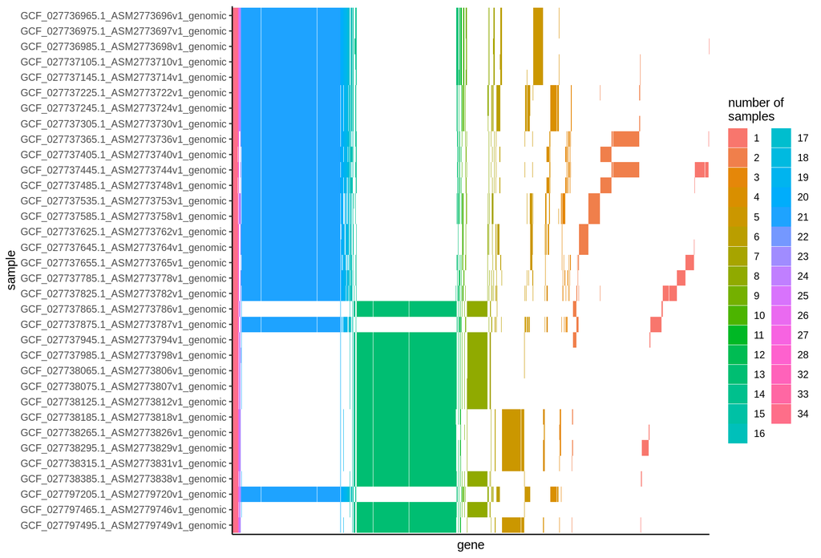

*Fig. 4: Genes shared between samples. Each vertical line represents a gene, and all lines have the same width regardless of the size of the gene. The genes are colored by the number of samples sharing them.*

## Mashtree phylogeny

[Mashtree](https://github.com/lskatz/mashtree) computes an approximation of ANI using the minhash distance measure. On these distances, a phylogenetic tree is then created using the neighbor-joining algorithm. The plotted tree is not rooted.

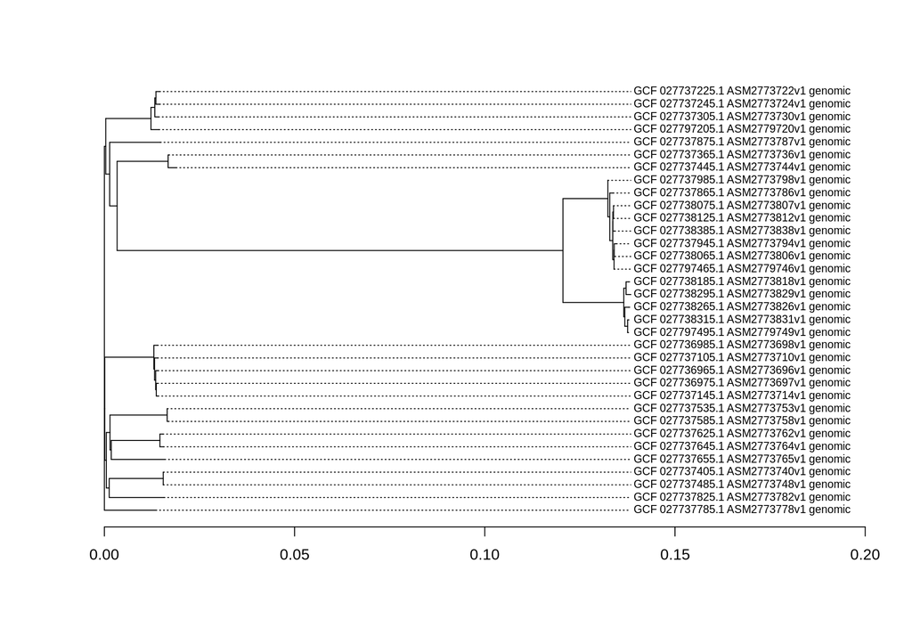

*Fig. 5: Approximation of a phylogenetic tree calculated with mashtree. The horizontal axis is equivalent to 1-ANI.*

[assemblycomparator2 v2.5.0](https://github.com/cmkobel/assemblycomparator2#assemblycomparator2) genomes to report pipeline. Copyright (C) 2019-2023 [Carl M. Kobel](https://github.com/cmkobel) [GNU GPL v3](https://github.com/cmkobel/assemblycomparator2/blob/master/LICENSE)